# **Exploratory Analysis**

This page contains a preliminary analysis of official discourse change. Here we trace change of frequency of appearance in the People’s Daily during the months after intensive military repressionss for both movements.

## Interactive Table

First, we provide an interactive table to present counts of terms in the front page of People’s Daily on each day from May 4, 1989 (one month before military repression of the movement) to July 3, 1989 (one month after military repression of the movement). This table may help get some sense of the terms that appear in the People’s Daily at that period of time. Sort dates, terms, and word counts using the arrow next to each column name.

| Datetime | term | count |
| --- | --- | --- |
| 1989-05-04 | 学生 | 12 |
| 1989-05-04 | 解决 | 11 |
| 1989-05-04 | 游行 | 11 |
| 1989-05-07 | 农业 | 21 |
| 1989-05-11 | 哈梅内伊 | 11 |
| 1989-05-14 | 对话 | 25 |
| 1989-05-15 | 主席 | 20 |
| 1989-05-15 | 戈尔巴乔夫 | 17 |
| 1989-05-15 | 学生 | 13 |
| 1989-05-15 | 主席 | 12 |

[output cut: 360 more lines]

## Preliminary Data Exploration of People’s Daily

Then, we again take the Tiananmen Square Movement in 1989 as an example and examine shifts in topics as well as frequency of terms before and after the repression of social movements:

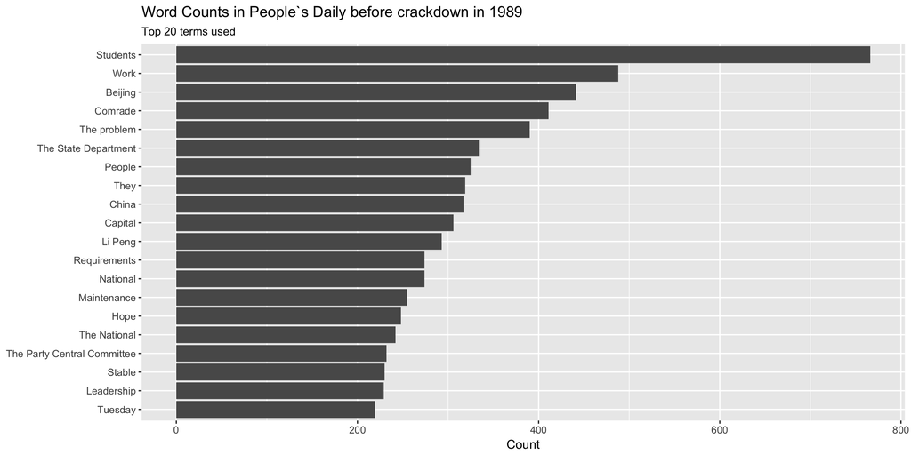

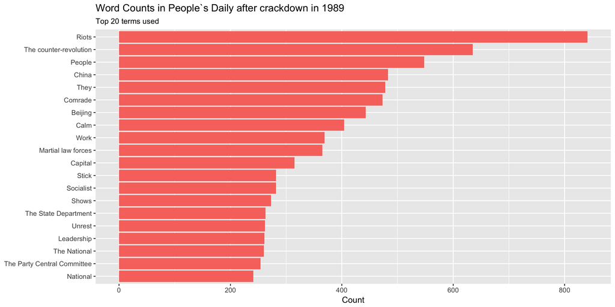

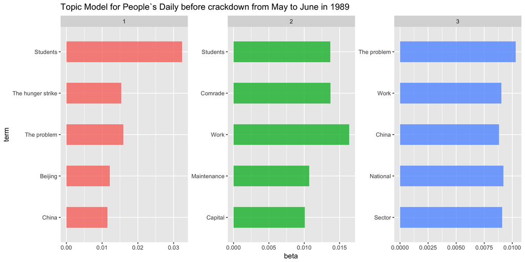

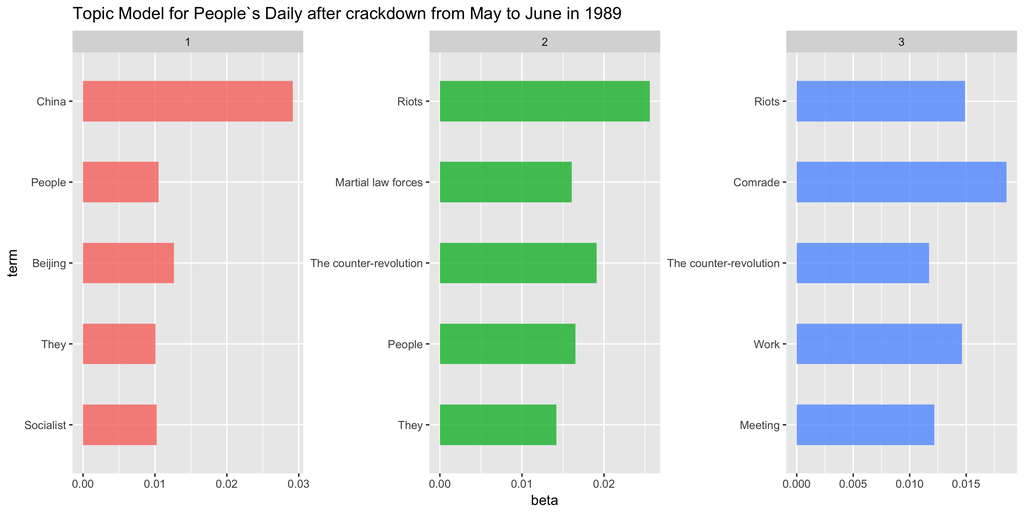

In the *People’s Daily*, before the intensive military repression of the movement, or so-called “crackdown” on June 4, 1989, terms such as students, work, and the problem appear more frequently, which may indicate a certain tolerance of government towards the students who staged the demonstration. However, after the crackdown, the *People’s Daily* changed its tone abruptly. It frequently used terms such as counter-revolution and riots, which may suggest its intent to disdain the movement.

## Binomial Statistical Analysis of Word Frequency Change

Here we conduct binomial statistical analysis to trace changes of frequency of key terms during 12 months after the repression for both movements. In both graphs as follow, dots represent terms, x-axis represents the change of appearance probability of given terms over 12 months. Positive numbers mark increases in frequency. Y-axis marks the p-value of frequency change. To be clear, we only present 50 terms whose extents of frequency change are the most among all words, and changes for all these selected terms are significant at the .05 level.

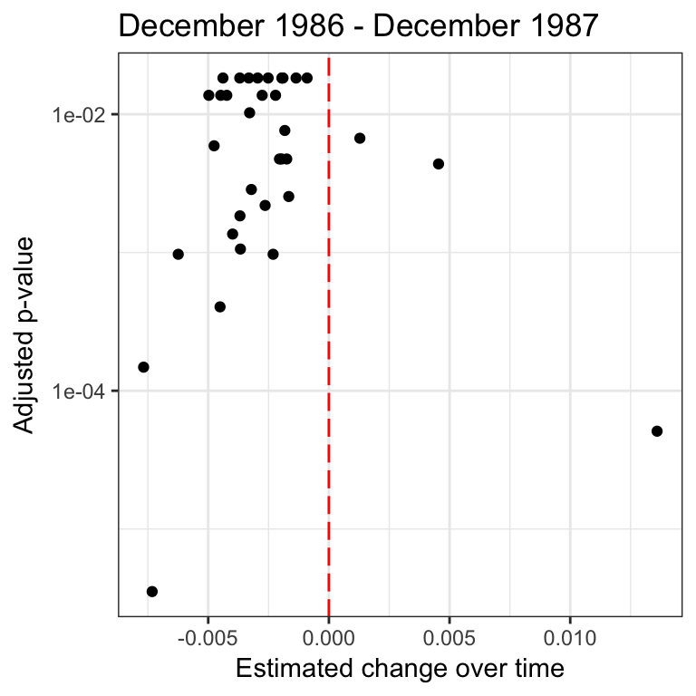

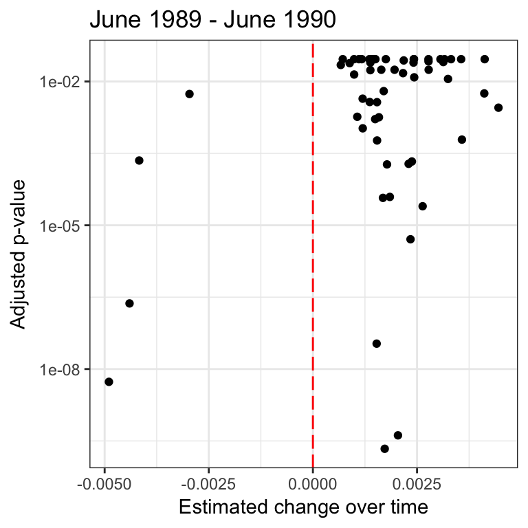

In the following two tables, we provide tables to show those terms that change most abruptly after the repression for both events. First we present the result table for the 1986 Student Demonstration, with the English translation of the key terms *(Note: “XIII” means the 13th National Congress of the Communist Party of China, which was held during October 25 to November 1, 1987)*.

| Chinese word | Engish translation | predicted frequency | standard error | p-value |
| --- | --- | --- | --- | --- |
| 十三大 | XIII | 0.01360 | 0.00283 | 0.00000 |
| 安定团结 | Stability and unity | -0.00768 | 0.00167 | 0.00000 |
| 平均 | Average | -0.00732 | 0.00138 | 0.00000 |
| 资产阶级自由化 | Bourgeois liberalization | -0.00624 | 0.00150 | 0.00003 |
| 反映 | Reflect | -0.00498 | 0.00150 | 0.00091 |
| 获得 | Get | -0.00476 | 0.00132 | 0.00031 |

Then we present the table for the Tiananmen Square Protest in 1989:

| Chinese word | Engish translation | predicted frequency | standard error | p-value |
| --- | --- | --- | --- | --- |
| 暴乱 | Riots | -0.00490 | 0.00076 | 0.00000 |
| 友谊 | Friendship | 0.00446 | 0.00112 | 0.00007 |
| 反革命 | The counter-revolution | -0.00440 | 0.00075 | 0.00000 |
| 平息 | Calm | -0.00417 | 0.00091 | 0.00000 |
| 一行 | Line | 0.00412 | 0.00135 | 0.00225 |
| 友好关系 | Friendly relations | 0.00411 | 0.00109 | 0.00017 |

Furthermore, we also plot the top six terms with greatest estimated frequency change in 1986 and 1989 respectively, as shown below:

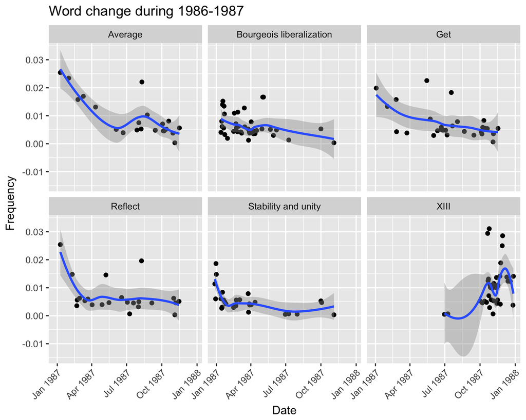

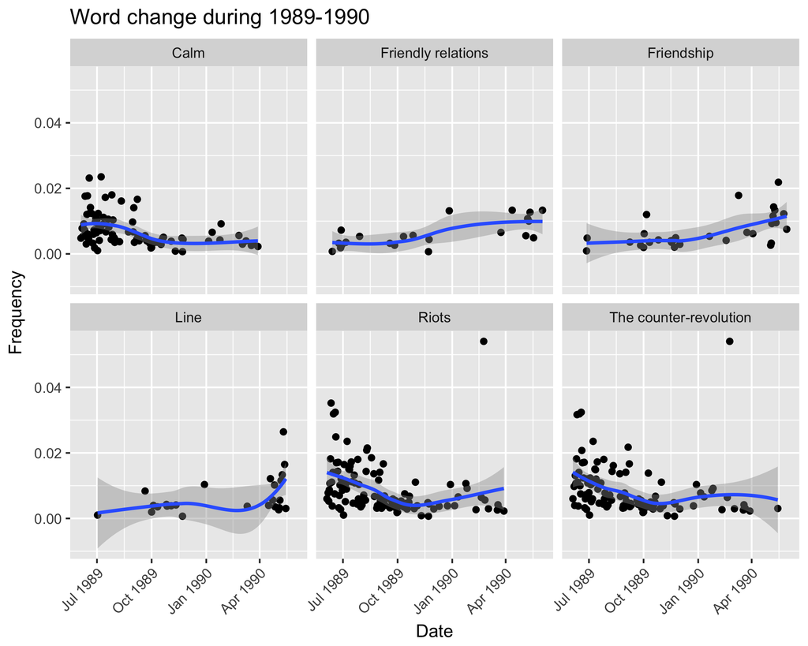

## Tentative Visualization of Selected Key Words

What are the relationships between characteristics of key words and their changes of frequency? To preliminary examine such relationships, we tentatively select four word pairs and plot their frequency change during the months after the repression of two movement events:

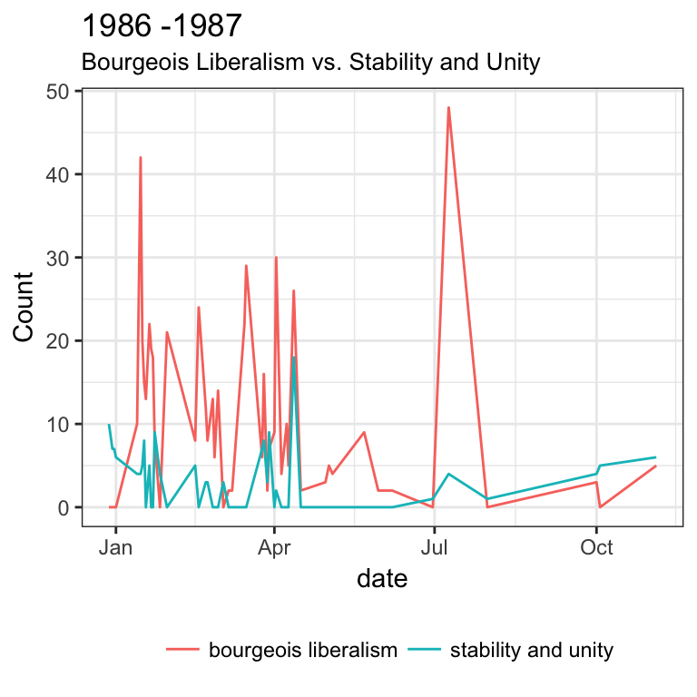

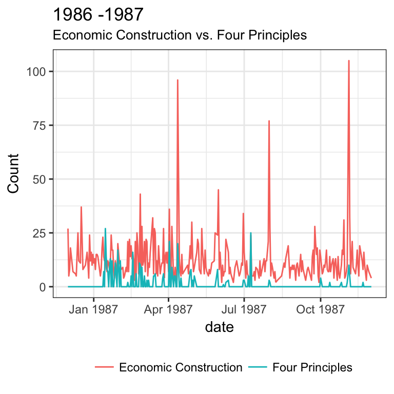

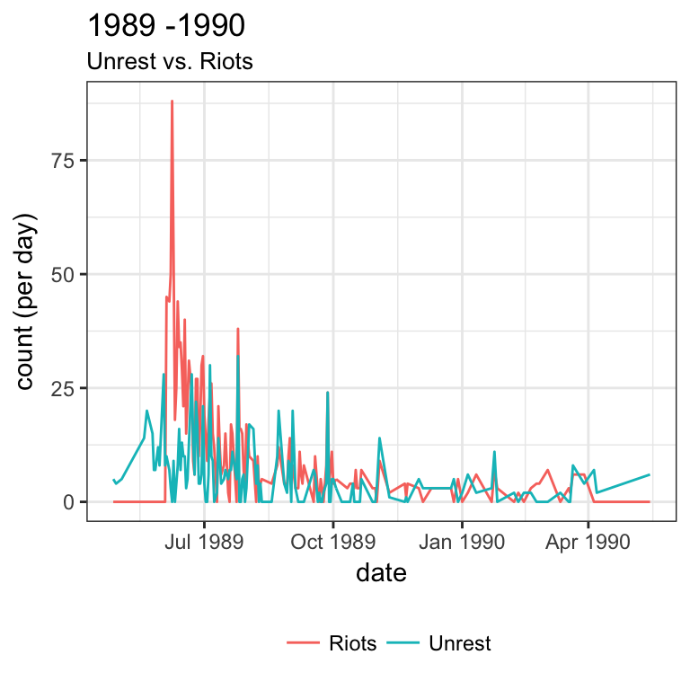

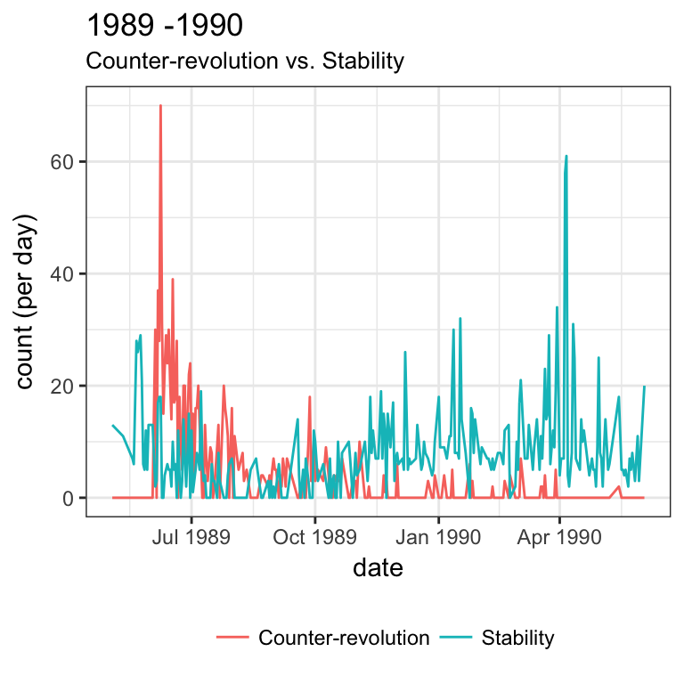